# Final Project

Santiago D. Barber

February 3rd 2026

```r
library(ggplot2)
library(DESeq2)
library(magrittr)
library(dplyr)
library(tidyr)
library(readr)
library(ggrepel)
library(tibble)
library(biomaRt)
library(readr)
library(purrr)
```

# Downloading & documenting the data

For this project, I will be analyzing the “BATLAS” dataset. This dataset has been fully uploaded to ENA with accession number `ERP022805`. Further information about the data can be found [here](https://www.ebi.ac.uk/ena/browser/view/ERP022805). To download the manifest of this study, we can use the following command:

```bash
wget -O ERP022805_read_run.tsv 'https://www.ebi.ac.uk/ena/portal/api/filereport?accession=ERP022805&result=read_run&fields=study_accession,sample_accession,secondary_sample_accession,experiment_accession,run_accession,scientific_name,experiment_title,fastq_ftp,sample_alias&format=tsv&download=true&limit=0'
```

Now, we can use a `while` loop to download all of the samples that have a `sample_alias` that starts with `E387`, since those are the ones we are interested in. To do this, we can pipe the output of the `awk` function (the ftp downlad links at column `$8`) into a `while` loop that uses `read` to store the download links into a variable `path`. Then, for each `path`, build the dowlonad url adding “ftp://” and run `wget`:

```bash
awk -F'\t' 'NR>1 && $9 ~ /^E387/ {print $8}' ERP022805_read_run.tsv |
while read -r path; do
  url="ftp://$path"
  echo "======= Starting download of $url"
  wget -c "$url"
done
```

For convenience, we can generate a `tsv` file that contains all of the information we might find useful for downstream analysis and differential gene expression analysis. To do this, we can use the following command. We first parse the first row (headers, `NR==1`) and store the column index of `sample_alias` and `run_accession`.

We then print the column names of the new file, and parse the stored variables to print the corresponding fields in each of the previously defined columns

```bash
awk -F'\t' '
BEGIN{OFS="\t"}
NR==1{ for (i=1;i<=NF;i++) {
    if ($i=="sample_alias") sa=i
    if ($i=="run_accession") ra=i}
  print "run_accession","sample_alias","sample_number","fat_type"
  next
}
sa && ra && $sa ~ /^E387_/{
  split($sa,a,"_")
  fat=a[3] "_" a[4]
  print $ra, $sa, a[2], fat}' \
  ERP022805_read_run.tsv > sample_table.tsv
```

## Original Publication

Perdikari A, Leparc GG, Balaz M, Pires ND, Lidell ME, Sun W, Fernandez-Albert F, Müller S, Akchiche N, Dong H, Balazova L, Opitz L, Röder E, Klein H, Stefanicka P, Varga L, Nuutila P, Virtanen KA, Niemi T, Taittonen M, Rudofsky G, Ukropec J, Enerbäck S, Stupka E, Neubauer H, Wolfrum C. **BATLAS: Deconvoluting Brown Adipose Tissue.** *Cell Reports.* 2018 Oct 16;25(3):784–797.e4

## Who generated the data

The BATLAS RNA-seq data (ENA study ERP022805) were generated by the BATLAS study team (referenced above). The main contributor was Christian Wolfrum’s group at the Institute of Food, Nutrition and Health, ETH Zürich.

Deep neck (brown adipose tissue, BAT) and adjacent white subcutaneous adipose tissue (WAT) samples were obtained from the lower third of the neck by an experienced ENT surgeon from 18 individuals (1 Male/ 17 Female) during neck surgery under general anesthesia, age between 22 to 73 years old and BMI between 19 to 34 kg/m2. The deep neck adipose tissue sample was taken from pre- and paravertebral space between the common carotid and trachea in case of thyroid surgery and just laterally to the carotid sheath in case of branchial cleft cyst surgery.

In all cases, the surgical approach was sufficient to reach and sample the deep neck adipose tissue without any additional morbidity. Patients with malignant disease and subjects younger than 18 years were excluded from participation in the study. Adipose tissue samples were immediately cleaned from blood and connective tissue, and frozen in liquid nitrogen until further processing. The clinical study on obese subjects (20/42 Male/Female; age 40.5 ± 1.6 years; BMI 41.2 ± 0.9 kg/m2) undergoing caloric restriction with a daily intake of 800 kcal was approved by the ethics committee at the Uni- versity Hospital of Heidelberg, Germany (S-365/2007). It conforms to the ethical guidelines of the 2000 Helsinki declaration. All participants provided witnessed written informed consent prior to entering the study. The study was registered as NCT00773565.

## How was the RNA extracted?

Total RNA was extracted from whole adipose tissues using Trizol reagent (Invitrogen) according to the manufacturer’s instructions.

## What library prep was used?

Deep neck BAT and subcutaneous white adipose tissue WAT RNA-Seq libraries were prepared using 25 ng of total RNA input with the TrueSeq RNA Sample Prep Kit v2 (Illumina) producing an average 275 bp fragment including adapters.

## How was mRNA enriched?

According to the TrueSeq RNA Sample Prep Kit v2 (Illumina) user manual, the messenger RNA is first purified using polyA selection, then chemically fragmented and converted into single-stranded cDNA using random hexamer priming.

## What cell type or tissue was used?

Brown adipose tissue (BAT) and white adipose tissue (WAT) from human deep neck surgeries

## What was the treatment/experimental condition?

The experimental condition would be Brown adipose tissue (BAT). We want to know what genes are differentially expressed in BAT vs WAT.

## What sequencing platform was used?

In the final step before RNA-Seq, eight individual libraries were normalized and pooled together using the adaptor indices supplied by the manufacturer. RNA-Seq was performed as 50 bp, single reads and 7 bases index read on an Illumina HiSeq2000 instrument. Approximately 20–30 million reads per sample were obtained.

## Citations

Orava, J., Nuutila, P., Lidell, M.E., Oikonen, V., Noponen, T., Viljanen, T., Scheinin, M., Taittonen, M., Niemi, T., Enerba ¨ ck, S., and Virtanen, K.A. (2011). Different metabolic responses of human brown adipose tissue to activation by cold and insulin. Cell Metab. 14, 272–279.

# Align the FASTQ file with an appropriate aligner

## Alignment

For aligning the data, I will first build an STAR index. Since the final objective of this small project is to merge the resulting transcript abundances with the GTEx data, I will use the same genome build and GENECODE version as [GTEx](https://www.gtexportal.org/home/releaseInfoPage).

First, lets download the genome annotation and the FASTA:

```bash
wget https://ftp.ebi.ac.uk/pub/databases/gencode/Gencode_human/release_39/gencode.v39.annotation.gtf.gz
gunzip -c gencode.v39.annotation.gtf.gz > gencode.v39.annotation.gtf

wget https://ftp.ebi.ac.uk/pub/databases/gencode/Gencode_human/release_39/GRCh38.primary_assembly.genome.fa.gz
gunzip GRCh38.primary_assembly.genome.fa.gz
```

To create the STAR index and align the samples, we can use the following script and `sbatch`. GTEx uses STAR version `2.7.10a` while our `angsd` environment uses `2.7.11a`. Ideally, we would like to use the same version to maximize cross-dataset comparability; but I will be using this environment to keep things more reproducible.

I will ask the slurm manager for 8 cpus per task so things more a little faster `{SLURM_CPUS_PER_TASK}`.

The file below will first check if the STAR index already exists in the specified `INDEX_DIR` and skip the index generation step if it does. This way, if we need to re-run the alignment for any reason, we won’t waste time regenerating the index. Then, it will loop through all FASTQ files in the `FASTQ_DIR`, align them using STAR, and output sorted BAM files to the `BAM_DIR`. Finally, it will index each BAM file with `samtools`.

For simplicity, I have hardcoded the paths in the script, but these can be easily modified to be passed as command-line arguments if needed.

For STAR alignment, I used mostly the default parameters. I used `--sjdbOverhang 49` so splice junction sequences are optimized for the read length when creating the INDEX. When running the alignment, I specified `outSAMattributes All` to get all of the attributes, and `--outSAMtype BAM SortedByCoordinate` so the outputs would be sorted and `BAM` instead of `SAM`. Then, I also indexed each `BAM` right after running STAR using `samtools index`.

`STAR_index_and_alignment.sh`:

```bash
#!/usr/bin/env bash
#SBATCH --job-name=star_hg38_v39
#SBATCH --output=STAR_RUN.out
#SBATCH --error=STAR_RUN.err
#SBATCH --time=24:00:00
#SBATCH --cpus-per-task=8
#SBATCH --mem=64G

set -euo pipefail

# User-configurable paths

PROJECT_DIR="/athena/angsd/scratch/sdb4002/Final_project"
INDEX_DIR="${PROJECT_DIR}/STAR_index_GENCODE_v39"
FASTQ_DIR="${PROJECT_DIR}/FASTQ"
BAM_DIR="${PROJECT_DIR}/BAMs"

# Fasta and GTF
GENOME_FA="/athena/angsd/scratch/sdb4002/Final_project/GRCh38.primary_assembly.genome.fa"
GTF_FILE="/athena/angsd/scratch/sdb4002/Final_project/gencode.v39.annotation.gtf"

# Since fastq files are 52bp
SJDB_OVERHANG=49

# Environment
source /home/fs01/sdb4002/miniconda3/etc/profile.d/conda.sh
conda activate angsd

# Build STAR index using downloaded reference and FASTA (GENCODE v39, GRCh38/hg38)
mkdir -p "${INDEX_DIR}"
mkdir -p "${BAM_DIR}"

if [[ -s "${INDEX_DIR}/Genome" && -s "${INDEX_DIR}/SA" && -s "${INDEX_DIR}/SAindex" ]]; then # check if the index already exist...
  echo "STAR index already exists in ${INDEX_DIR}; skipping Index creation."
else
  echo "STAR index not found (or incomplete); generating in ${INDEX_DIR}..."
  STAR \
    --runMode genomeGenerate \
    --runThreadN "${SLURM_CPUS_PER_TASK}" \
    --genomeDir "${INDEX_DIR}" \
    --genomeFastaFiles "${GENOME_FA}" \
    --sjdbGTFfile "${GTF_FILE}" \
    --sjdbOverhang "${SJDB_OVERHANG}"

# Align each FASTQ in FASTQ directory and write BAMs to BAM directory
shopt -s nullglob # so it does not crash if FASTQs are not found
FASTQS=("${FASTQ_DIR}"/*.fastq.gz)
(( ${#FASTQS[@]} > 0 )) || { echo "No FASTQs found in ${FASTQ_DIR}" >&2; exit 1; }

for fastq in "${FASTQS[@]}"; do
  sample="$(basename "${fastq}" .fastq.gz)"
  prefix="${BAM_DIR}/${sample}.STAR."

  STAR \
    --runMode alignReads \
    --runThreadN "${SLURM_CPUS_PER_TASK:-1}" \
    --genomeDir "${INDEX_DIR}" \
    --readFilesIn "${fastq}" \
    --readFilesCommand zcat \
    --outFileNamePrefix "${prefix}" \
    --outSAMattributes All \
    --outSAMtype BAM SortedByCoordinate

  samtools index "${prefix}Aligned.sortedByCoord.out.bam"
done
```

## FastQC

For FastQC and MultiQC, I ran it on an interactive session on the terminal using

```bash
mkdir FASTQC_BAM && mkdir MULTIQC_BAM

BAMS=(/athena/angsd/scratch/sdb4002/Final_project/BAMs/*.bam)

for bam in "${BAMS[@]}"; do
  fastqc -o "/athena/angsd/scratch/sdb4002/Final_project/FASTQC_BAM" "${bam}"
done
```

```bash
conda activate multiqc
multiqc "/athena/angsd/scratch/sdb4002/Final_project/FASTQC_BAM" \
  -o "/athena/angsd/scratch/sdb4002/Final_project/MULTIQC_BAM" \
  -n multiqc_bam_fastqc_report
```

Looking at the FASTQC results, I see that all samples fail `Per base sequence content` but there are no overrepresented sequences or adapter contamination. This could be caused by random hexamer priming bias (the “random” primers aren’t perfectly random).

The analysis also fails `Sequence duplication levels`, with only around 20% of the reads remaining if the samples were to be deduplicated. Since FASTQ cannot tell PCR duplicates from “real” duplicates of abundant transcripts because it looks at raw sequences only.

```r
knitr::include_graphics("MultiQC.png")
```

[output not shown]

Otherise, the QC analysis looks okay. I will check what sequences are overrepresented to have an idea of what is driving these sequence duplication observations

```bash
zcat ERR2225804.fastq.gz | awk 'NR%4==2' | sort | uniq -c | sort -nr | head -20
```

```
  10819 CTTGGATTAAGGCGACAGCGATTTCTAGGATAGTCAGTAGAATTAGAATTGT
   8956 CCCGTATCGAAGGCCTTTTTGGACAGGTGGTGTGTGGTGGCCTTGGTATGTG
   8925 CCGTCATCTACTCTACCATCTTTGCAGGCACACTCATCACAGCGCTAAGCTC
   7545 CAAGACGCTACTTCCCCTATCATAGAAGAGCTTATCACCTTTCATGATCACG
   7373 CCAAAATGAACGAAAATCTGTTCGCTTCATTCATTGCCCCCACAATCCTAGG
   7019 CCCAAACCCACTCCACCTTACTACCAGACAACCTTAGCCAAACCATTTACCC
   6737 CTAGCATTTACCATCTCACTTCTAGGAATACTAGTATATCGCTCACACCTCA
   6417 CACATGCCTATCATATAGTAAAACCCAGCCCATGACCCCTAACAGGGGCCCT
   6337 GTTTGGTCTAGGGTGTAGCCTGAGAATAGGGGAAATCAGTGAATGAAGCCTC
   6213 GTCGTGTAGTACGATGTCTAGTGATGAGTTTGCTAATACAATGCCAGTCAGG
   6189 CTCAAATCATGAAAATTATTAATATTACTGCTGTTAGAGAAATGAATGAGCC
   6039 CCAAAATCCATTTCACTATCATATTCATCGGCGTAAATCTAACTTTCTTCCC
   5814 GTGGAAGTGAGCTACAACGTAGTACGTGTCGTGTAGTACGATGTCTAGTGAT
   5582 CTAAATACTACCGTATGGCCCACCATAATTACCCCCATACTCCTTACACTAT
   5263 GTAAAACCCAGCCCATGACCCCTAACAGGGGCCCTCTCAGCCCTCCTAATGA
   5161 CTGAGATGTTAGTATTAGTTAGTTTTGTTGTGAGTGTTAGGAAAAGGGCATA
   5101 GTTTGATTAGTCATTGTTGGGTGGTGATTAGTCGGTTGTTGATGAGATATTT
   5032 CTGGCATTGTATTAGCAAACTCATCACTAGACATCGTACTACACGACACGTA
   5017 CTGCTGTTAGAGAAATGAATGAGCCTACAGATGATAGGATGTTTCATGTGGT
   5016 AAATGAATGAGCCTACAGATGATAGGATGTTTCATGTGGTGTATGCATCGGG
```

Upon conducting a BLAST search, most of these highly duplicated sequences come from mitochondrial genes. BAT is a tissue highly enriched in mitocondria, so it is no surprising to find this type of enrichment. However, WAT should not be as enriched. To check this, we will check the percentage of reads aligning to the mitochondrion `chrM`:

```bash
for bam in *.bam; do
  printf "%s\t" "$bam"
  samtools idxstats "$bam" | awk 'BEGIN{mt=0; tot=0}
         {tot += $3}
         ($1=="MT" || $1=="chrM") {mt = $3}
         END {
           if (tot==0) {printf("MT reads: %d / %d (NA)\n", mt, tot); exit}
           printf("MT reads: %d / %d (%.2f%%)\n", mt, tot, 100*mt/tot)
         }'
done
```

```
ERR2225804.STAR.Aligned.sortedByCoord.out.bam   MT reads: 7076507 / 32789062 (21.58%)
ERR2225805.STAR.Aligned.sortedByCoord.out.bam   MT reads: 4870472 / 28969581 (16.81%)
ERR2225806.STAR.Aligned.sortedByCoord.out.bam   MT reads: 4038709 / 32059933 (12.60%)
ERR2225807.STAR.Aligned.sortedByCoord.out.bam   MT reads: 4838939 / 32202031 (15.03%)
ERR2225808.STAR.Aligned.sortedByCoord.out.bam   MT reads: 10036141 / 30709186 (32.68%)
ERR2225809.STAR.Aligned.sortedByCoord.out.bam   MT reads: 4447025 / 36458272 (12.20%)
ERR2225810.STAR.Aligned.sortedByCoord.out.bam   MT reads: 7328692 / 32043409 (22.87%)
ERR2225811.STAR.Aligned.sortedByCoord.out.bam   MT reads: 4280930 / 31122168 (13.76%)
ERR2225812.STAR.Aligned.sortedByCoord.out.bam   MT reads: 16945371 / 31865569 (53.18%)
ERR2225813.STAR.Aligned.sortedByCoord.out.bam   MT reads: 5330467 / 33934060 (15.71%)
ERR2225814.STAR.Aligned.sortedByCoord.out.bam   MT reads: 8937631 / 30847538 (28.97%)
ERR2225815.STAR.Aligned.sortedByCoord.out.bam   MT reads: 5046633 / 28589238 (17.65%)
ERR2225816.STAR.Aligned.sortedByCoord.out.bam   MT reads: 11707747 / 37042422 (31.61%)
ERR2225817.STAR.Aligned.sortedByCoord.out.bam   MT reads: 5155179 / 30675231 (16.81%)
ERR2225818.STAR.Aligned.sortedByCoord.out.bam   MT reads: 8408498 / 28732392 (29.26%)
ERR2225819.STAR.Aligned.sortedByCoord.out.bam   MT reads: 2909748 / 30491456 (9.54%)
ERR2225820.STAR.Aligned.sortedByCoord.out.bam   MT reads: 7829343 / 32235658 (24.29%)
ERR2225821.STAR.Aligned.sortedByCoord.out.bam   MT reads: 4269606 / 31373385 (13.61%)
ERR2225822.STAR.Aligned.sortedByCoord.out.bam   MT reads: 4777305 / 30491358 (15.67%)
```

We can calculate the average percentage of reads that map to `chrM` across the two different sample groups that we are studying:

## Gene-level quantification with featureCounts

After alignment, the next step is to summarize reads to genes and build a raw counts matrix for downstream differential expression analysis. For this, we can use `featureCounts` from the Subread package on the coordinate-sorted BAM files produced by STAR. Because these data are single-end, we do not use paired-end options. We count reads overlapping `exon` features and summarize them at the `gene_id` level using the same GENCODE v39 annotation that was used for alignment.

`Feature_counts.sh`:

```bash
#!/usr/bin/env bash
#SBATCH --job-name=featurecounts_batlas
#SBATCH --output=/athena/angsd/scratch/sdb4002/Final_project/featureCounts.out
#SBATCH --error=/athena/angsd/scratch/sdb4002/Final_project/featureCounts.err
#SBATCH --time=08:00:00
#SBATCH --cpus-per-task=8
#SBATCH --mem=32G

set -euo pipefail
shopt -s nullglob

PROJECT_DIR="/athena/angsd/scratch/sdb4002/Final_project"
BAM_DIR="${PROJECT_DIR}/BAMs"
COUNTS_DIR="${PROJECT_DIR}/counts"
GTF_FILE="${PROJECT_DIR}/gencode.v39.annotation.gtf"

source /home/fs01/sdb4002/miniconda3/etc/profile.d/conda.sh
conda activate angsd

mkdir -p "${COUNTS_DIR}"

BAMS=("${BAM_DIR}"/*.bam)
(( ${#BAMS[@]} > 0 )) || { echo "No BAM files found in ${BAM_DIR}" >&2; exit 1; }

featureCounts \
  -T "${SLURM_CPUS_PER_TASK:-1}" \
  -a "${GTF_FILE}" \
  -o "${COUNTS_DIR}/BATLAS_featureCounts.txt" \
  -t exon \
  -g gene_id \
  "${BAMS[@]}"
```

[output not shown]

The `featureCounts` output includes annotation columns followed by one column per BAM file. To generate a cleaner gene-by-sample counts matrix, we can keep only the gene identifier and sample count columns, while changing the sample names to the `sample_alias` from our `sample_table.tsv` for better readability. We can do this with the following `awk` command:

```bash
awk 'BEGIN{FS=OFS="\t"}
FNR==NR {
  if (FNR > 1) alias[$1] = $2 # store sample_alias by run_accession from sample_table
  next
}
/^#/ {next}
$1 == "Geneid" && !seen_header {
  printf "Geneid"
  for (i=7; i<=NF; i++) {
    sample = $i # get the sample name from the header
    sub(/^.*\//, "", sample) # strip path
    sub(/\.STAR\.Aligned\.sortedByCoord\.out\.bam$/, "", sample) # strip STAR suffix
    printf OFS alias[sample] # replace with sample_alias
  }
  printf "\n"
  seen_header = 1
  next
}
$1 != "Geneid" { # for data rows, keep geneid and counts
  printf $1 # "Geneid"
  for (i=7; i<=NF; i++) printf OFS $i #
  printf "\n"
}' /athena/angsd/scratch/sdb4002/Final_project/sample_table.tsv \
   /athena/angsd/scratch/sdb4002/Final_project/counts/BATLAS_featureCounts.txt \
   > /athena/angsd/scratch/sdb4002/Final_project/counts/BATLAS_counts_matrix.tsv
```

This `BATLAS_counts_matrix.tsv` file contains raw gene counts, with genes in rows and samples in columns, and can be used directly as input for tools such as `DESeq2` or `edgeR`.

## RSeQC for RNA-seq QC on BAM files

We can use the `read_distribution.py` from RSeQC on an aligned and sorted BAM file to check what genomic features the reads are mapping to. This can help us understand the quality of our RNA-seq data and whether we have a good representation of different gene features (exons, introns, intergenic regions, etc.).

First, lets get a `BED` file. Since we don’t have write permisions to modify the enviroments, I created my own:

```bash
conda create -y -n RSeQC \
  python=3.10 \
  rseqc \
  samtools \
  ucsc-gtftogenepred \
  ucsc-genepredtobed \
  -c conda-forge -c bioconda
```

```bash
conda activate RSeQC

gtfToGenePred gencode.v39.annotation.gtf gencode.v39.annotation.genePred
genePredToBed gencode.v39.annotation.genePred gencode.v39.annotation.bed
```

```bash
BAMS="/athena/angsd/scratch/sdb4002/Final_project/BAMs"
BED="/athena/angsd/scratch/sdb4002/Final_project/gencode.v39.annotation.bed"
OUT_DIR="/athena/angsd/scratch/sdb4002/Final_project/RSeQC_read_distribution"

for bam in "$BAMS"/*.bam; do
  sample=$(basename "$bam" .bam)
  read_distribution.py -i "$bam" -r "$BED" > "$OUT_DIR/${sample}.read_distribution.txt"
done
```

To get a summary table, we can parse the output files with the following `bash` command. This will extract the percentage of reads mapping to different genomic features for each sample and compile it into a single `tsv` file.

```bash
OUT_DIR="/athena/angsd/scratch/sdb4002/Final_project/RSeQC_read_distribution"

{
  printf "sample\tgroup\tpercent\n"
  for file in "$OUT_DIR"/*.read_distribution.txt; do
    sample=$(basename "$file" .read_distribution.txt)
    awk -v s="$sample" '
      $1 == "Total" && $2 == "Assigned" && $3 == "Tags" { # store the total number of assigned reads for this sample
        assigned = $4 # the number of reads assigned to any feature
      }
      $1 ~ /^(CDS_Exons|5'\''UTR_Exons|3'\''UTR_Exons|Introns|TSS_up_10kb|TES_down_10kb)$/ && assigned > 0 {
        percent = ($3 / assigned) * 100 # calculate percentage of reads mapping to this feature
        printf "%s\t%s\t%.2f\n", s, $1, percent
      }
    ' "$file"
  done
} > "$OUT_DIR/read_distribution_summary.tsv"
```

To visualize the distribution:

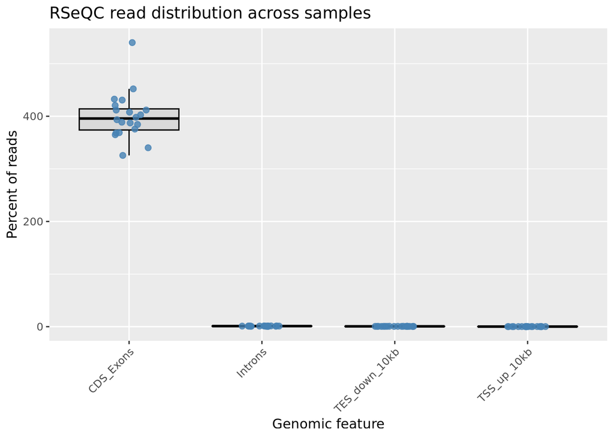

```r
ggplot(read_tsv("read_distribution_summary.tsv"), aes(x = group, y = percent)) +
  geom_boxplot(outlier.shape = NA, fill = "grey85", color = "black") +
  geom_jitter(width = 0.15, size = 2, alpha = 0.8, color = "steelblue") +
  labs(
    x = "Genomic feature",
    y = "Percent of reads",
    title = "RSeQC read distribution across samples") +
  theme(axis.text.x = element_text(angle = 45, hjust = 1))
```

## DESeq2 analysis of BAT vs WAT differential expression

Following the workflow from the practical, we first import the raw count matrix, generate the sample metadata table, and build a `DESeqDataSet`. At this stage, the objective is to prepare and normalize the count data appropriately before carrying out the actual statistical testing for differential expression.

```r
RawCounts <- read.table("BATLAS_counts_matrix.tsv", header = TRUE, sep = "\t", check.names = FALSE)
SampleTable <- read.table("sample_table.tsv", header = TRUE, sep = "\t", stringsAsFactors = FALSE)

row.names(RawCounts) <- make.names(RawCounts$Geneid, unique = TRUE)
RawCounts <- as.matrix(RawCounts[, -1])

SampleTable$condition <- ifelse(grepl("^brown", SampleTable$fat_type, ignore.case = TRUE), "BAT", "WAT")
SampleTable <- SampleTable[, c("run_accession", "sample_alias", "sample_number", "fat_type", "condition")]
row.names(SampleTable) <- SampleTable$sample_alias

SampleTable <- SampleTable[colnames(RawCounts), , drop = FALSE]
SampleTable$condition <- factor(SampleTable$condition, levels = c("WAT", "BAT"))

dds_batlas <- DESeqDataSetFromMatrix(
  countData = RawCounts,
  colData = SampleTable,
  design = ~ condition)

dds_batlas
```

```
## class: DESeqDataSet
## dim: 61533 20
## metadata(1): version
## assays(1): counts
## rownames(61533): ENSG00000223972.5 ENSG00000227232.5 ...
##   ENSG00000210195.2 ENSG00000210196.2
## rowData names(0):
## colnames(20): E387_5_brown_fat E387_6_white_fat ... E387_31_brown_fat
##   E387_32_white_fat
## colData names(5): run_accession sample_alias sample_number fat_type
##   condition
```

```r
head(counts(dds_batlas), n=2)
```

```
##                   E387_5_brown_fat E387_6_white_fat E387_7_brown_fat
## ENSG00000223972.5                1                0                0
## ENSG00000227232.5                0                0                0
##                   E387_8_white_fat E387_9_brown_fat E387_10_white_fat
## ENSG00000223972.5                0                0                 0
## ENSG00000227232.5                0                0                 0
##                   E387_11_brown_fat E387_12_white_fat E387_13_brown_fat
## ENSG00000223972.5                 0                 0                 0
## ENSG00000227232.5                 0                 1                 0
##                   E387_14_white_fat E387_15_brown_fat E387_16_white_fat
## ENSG00000223972.5                 0                 0                 0
## ENSG00000227232.5                 0                 0                 0
##                   E387_17_brown_fat E387_18_white_fat E387_23_brown_fat
## ENSG00000223972.5                 1                 0                 0
## ENSG00000227232.5                 0                 1                 0
##                   E387_24_white_fat E387_27_brown_fat E387_28_white_fat
## ENSG00000223972.5                 0                 0                 0
## ENSG00000227232.5                 0                 0                 0
##                   E387_31_brown_fat E387_32_white_fat
## ENSG00000223972.5                 0                 0
## ENSG00000227232.5                 2                 3
```

```r
as.data.frame(colData(dds_batlas))
```

```
##                   run_accession      sample_alias sample_number  fat_type
## E387_5_brown_fat     ERR2225804  E387_5_brown_fat             5 brown_fat
## E387_6_white_fat     ERR2225805  E387_6_white_fat             6 white_fat
## E387_7_brown_fat     ERR2225806  E387_7_brown_fat             7 brown_fat
## E387_8_white_fat     ERR2225807  E387_8_white_fat             8 white_fat
## E387_9_brown_fat     ERR2225808  E387_9_brown_fat             9 brown_fat
## E387_10_white_fat    ERR2225809 E387_10_white_fat            10 white_fat
## E387_11_brown_fat    ERR2225810 E387_11_brown_fat            11 brown_fat
## E387_12_white_fat    ERR2225811 E387_12_white_fat            12 white_fat
## E387_13_brown_fat    ERR2225812 E387_13_brown_fat            13 brown_fat
## E387_14_white_fat    ERR2225813 E387_14_white_fat            14 white_fat
## E387_15_brown_fat    ERR2225814 E387_15_brown_fat            15 brown_fat
## E387_16_white_fat    ERR2225815 E387_16_white_fat            16 white_fat
## E387_17_brown_fat    ERR2225816 E387_17_brown_fat            17 brown_fat
## E387_18_white_fat    ERR2225817 E387_18_white_fat            18 white_fat
## E387_23_brown_fat    ERR2225818 E387_23_brown_fat            23 brown_fat
## E387_24_white_fat    ERR2225819 E387_24_white_fat            24 white_fat
## E387_27_brown_fat    ERR2225820 E387_27_brown_fat            27 brown_fat
## E387_28_white_fat    ERR2225821 E387_28_white_fat            28 white_fat
## E387_31_brown_fat    ERR2225822 E387_31_brown_fat            31 brown_fat
## E387_32_white_fat    ERR2225823 E387_32_white_fat            32 white_fat
##                   condition
## E387_5_brown_fat        BAT
## E387_6_white_fat        WAT
## E387_7_brown_fat        BAT
## E387_8_white_fat        WAT
## E387_9_brown_fat        BAT
## E387_10_white_fat       WAT
## E387_11_brown_fat       BAT
## E387_12_white_fat       WAT
## E387_13_brown_fat       BAT
## E387_14_white_fat       WAT
## E387_15_brown_fat       BAT
## E387_16_white_fat       WAT
## E387_17_brown_fat       BAT
## E387_18_white_fat       WAT
## E387_23_brown_fat       BAT
## E387_24_white_fat       WAT
## E387_27_brown_fat       BAT
## E387_28_white_fat       WAT
## E387_31_brown_fat       BAT
## E387_32_white_fat       WAT
```

As in the practical, it is useful to inspect the library sizes and remove genes with zero counts across all samples before normalization.

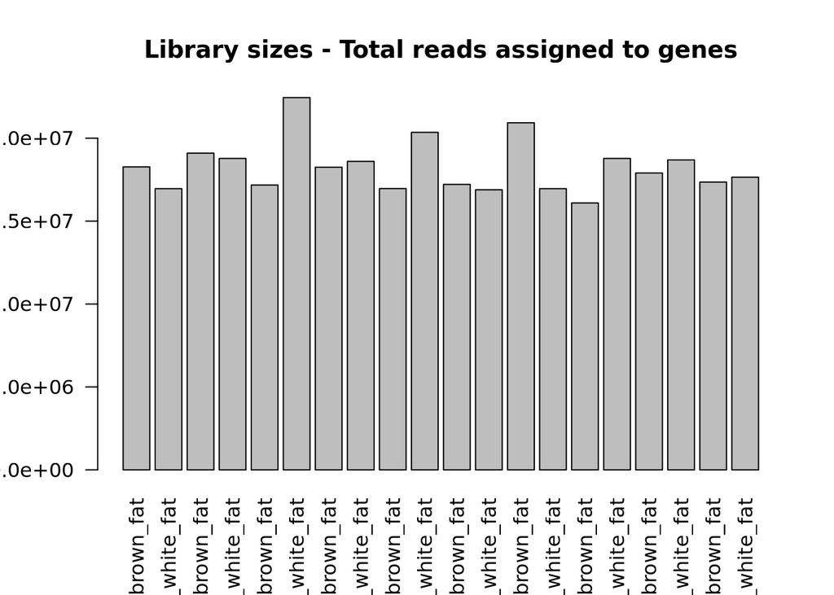

```r
colSums(counts(dds_batlas)) %>% barplot(
  las = 2,
  main = "Library sizes - Total reads assigned to genes")
```

```r
keep_genes <- rowSums(counts(dds_batlas)) > 0 # keep only those that have expression
dds_batlas <- dds_batlas[keep_genes, ]

dim(dds_batlas)
```

```
## [1] 43317    20
```

Next, we estimate DESeq2 size factors to account for differences in sequencing depth and RNA composition across samples. This gives us normalized counts that are more comparable across BAT and WAT.

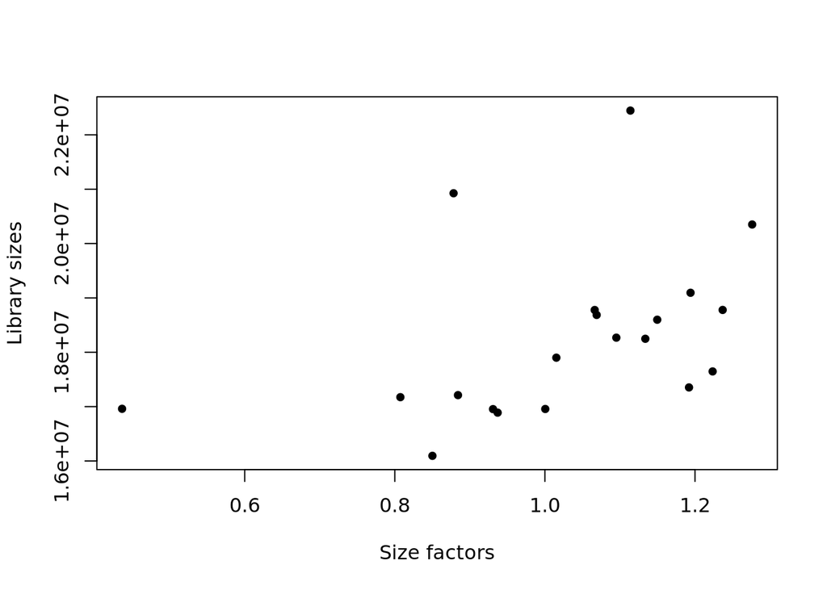

```r
dds_batlas <- estimateSizeFactors(dds_batlas)

plot(
  sizeFactors(dds_batlas),
  colSums(counts(dds_batlas)),
  xlab = "Size factors",
  ylab = "Library sizes",
  cex = 0.8, # make points smaller for better visibility
  pch = 19) # solid points
```

```r
counts_sf_normalized <- counts(dds_batlas, normalized = TRUE)
```

Compare the distributions of raw and normalized counts on the log scale:

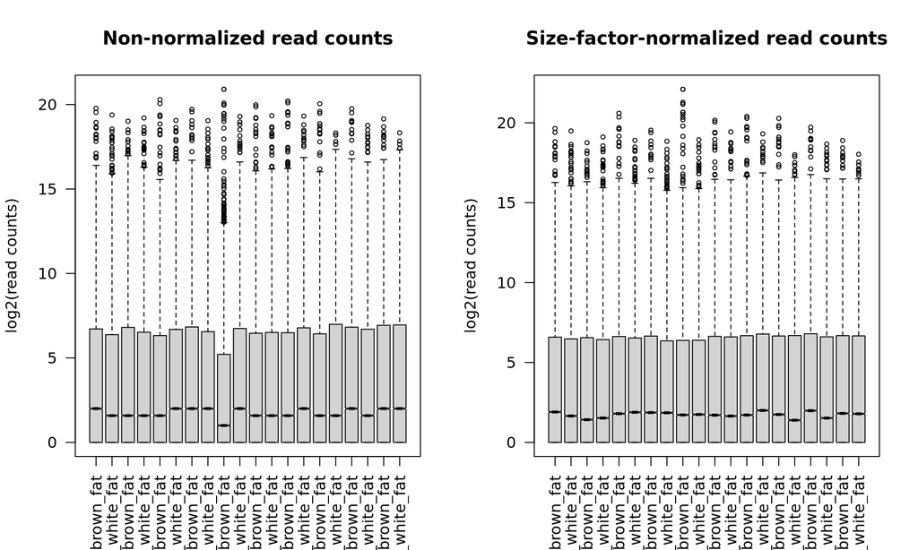

```r
par(mfrow = c(1, 2))

boxplot(
  log2(counts(dds_batlas) + 1),
  notch = TRUE,
  main = "Non-normalized read counts",
  ylab = "log2(read counts)",
  cex = 0.6,
  las = 2)

boxplot(
  log2(counts(dds_batlas, normalized = TRUE) + 1),
  notch = TRUE,
  main = "Size-factor-normalized read counts",
  ylab = "log2(read counts)",
  cex = 0.6,
  las = 2)
```

To stabilize the variance for exploratory analyses such as clustering or PCA (heterskedacity violate underlaying assumptions), we can use the `rlog` transformation.

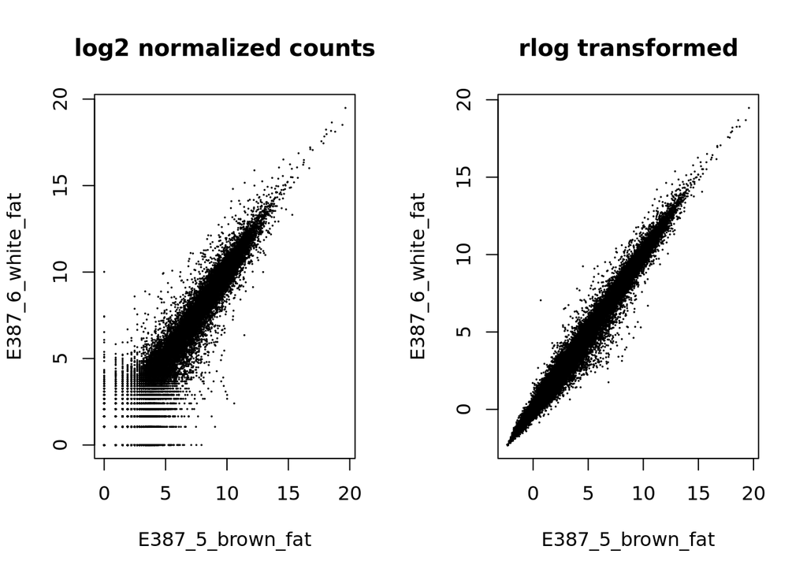

```r
assay(dds_batlas, "log_counts") <- log2(counts(dds_batlas, normalized = FALSE) + 1)
assay(dds_batlas, "log_norm_counts") <- log2(counts(dds_batlas, normalized = TRUE) + 1)

dst_rlog <- rlog(dds_batlas, blind = TRUE)
rlog_norm_counts <- assay(dst_rlog)

par(mfrow = c(1, 2))
plot(
  assay(dds_batlas, "log_norm_counts")[, 1:2],
  cex = 0.1,
  main = "log2 normalized counts")

plot(
  assay(dst_rlog)[, 1:2],
  cex = 0.1,
  main = "rlog transformed",
  xlab = colnames(assay(dst_rlog[, 1])),
  ylab = colnames(assay(dst_rlog[, 2])))
```

Using the variance-stabilized `rlog` values, we can now run a PCA to visualize the main axes of variation across samples and assess whether BAT and WAT separate globally.

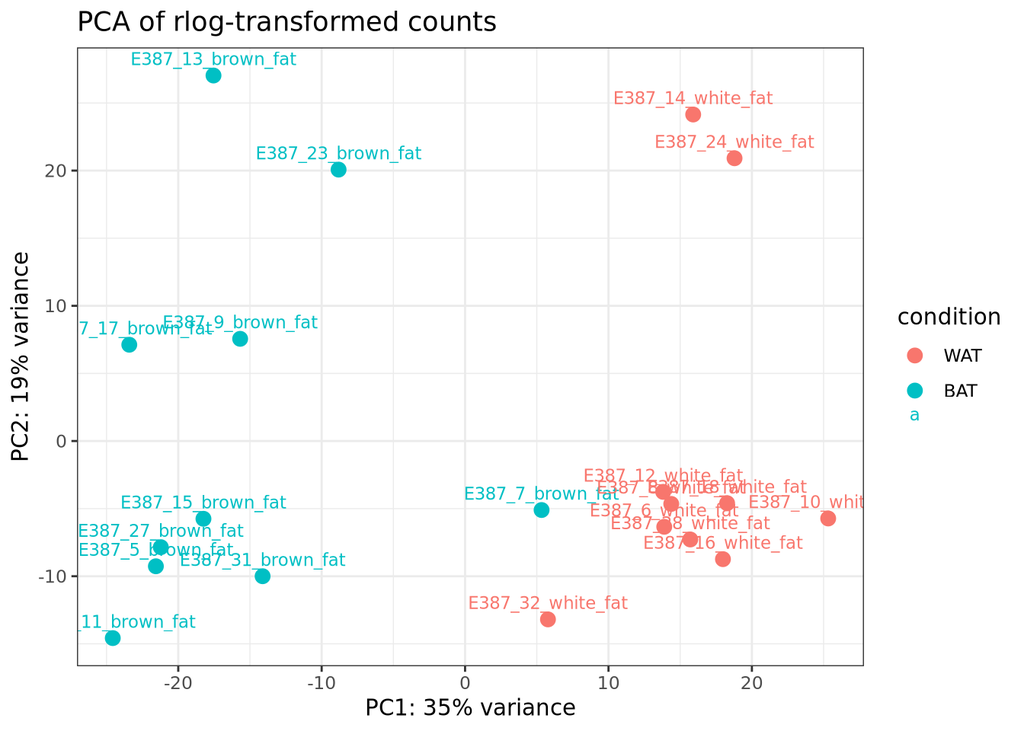

```r
pca_data <- plotPCA(dst_rlog, intgroup = "condition", returnData = TRUE, ntop=500)
percent_var <- round(100 * attr(pca_data, "percentVar"))

ggplot(pca_data, aes(PC1, PC2, color = condition, label = name)) +
  geom_point(size = 3) +
  geom_text(vjust = -0.8, size = 3) +
  xlab(paste0("PC1: ", percent_var[1], "% variance")) +
  ylab(paste0("PC2: ", percent_var[2], "% variance")) +
  ggtitle("PCA of rlog-transformed counts") +
  theme_bw()
```

PC1 shows a modest 35% variance, but it is enough to separate most of the BAT samples from the WAT samples, except for `E387_7_brown_fat` that clusters with WAT instead. PC2 captures around 19% of the variance and shows some separation within the BAT samples, but does not clearly separate BAT from WAT.

This shows that `E387_7_brown_fat` is relatively similar to the `WAT` samples. Since this are human samples taken surgically from patients and Brown adipose tissue is difficult to identify in adult humans, perhaps this sample has a higher proportion of white adipose tissue in it.

Finally, we can run the standard DESeq2 differential expression workflow comparing BAT against WAT and extract the results table.

```r
dds_batlas <- DESeq(dds_batlas)
res_bat_vs_wat <- results(dds_batlas, contrast = c("condition", "BAT", "WAT"))
res_bat_vs_wat <- res_bat_vs_wat[order(res_bat_vs_wat$padj), ]

head(as.data.frame(res_bat_vs_wat))
```

```
##                      baseMean log2FoldChange     lfcSE      stat       pvalue
## ENSG00000245694.11  561.08557      -3.826922 0.2027650 -18.87368 1.877452e-79
## ENSG00000135903.20   85.99240      -6.586202 0.4366488 -15.08352 2.078836e-51
## ENSG00000133026.14 2919.07127      -1.573155 0.1107666 -14.20243 8.849132e-46
## ENSG00000147883.12 1012.58415      -2.782171 0.2218075 -12.54318 4.332589e-36
## ENSG00000253293.6    45.79541       5.600496 0.4732061  11.83522 2.566808e-32
## ENSG00000204388.7  4418.74864      -4.317645 0.3740109 -11.54417 7.900245e-31
##                            padj
## ENSG00000245694.11 4.978628e-75
## ENSG00000135903.20 2.756329e-47
## ENSG00000133026.14 7.822043e-42
## ENSG00000147883.12 2.872290e-32
## ENSG00000253293.6  1.361332e-28
## ENSG00000204388.7  3.491645e-27
```

```r
summary(res_bat_vs_wat)
```

```
##
## out of 43313 with nonzero total read count
## adjusted p-value < 0.1
## LFC > 0 (up)       : 2622, 6.1%
## LFC < 0 (down)     : 2492, 5.8%
## outliers [1]       : 0, 0%
## low counts [2]     : 16799, 39%
## (mean count < 1)
## [1] see 'cooksCutoff' argument of ?results
## [2] see 'independentFiltering' argument of ?results
```

Lets visualize the results! For readability, I will use `biomaRt` to retrieve HGNC symbols and use those as row names in the `Vulcano` table when available.

```r
library(biomaRt)

Vulcano <- as.data.frame(res_bat_vs_wat)
Vulcano$ensembl_gene_id <- sub("\\..*$", "", rownames(Vulcano)) # remove version tail

gene_map <- tryCatch({
  mart <- useEnsembl(biomart = "genes", dataset = "hsapiens_gene_ensembl")
  out <- getBM(
    attributes = c("ensembl_gene_id", "hgnc_symbol"),
    filters = "ensembl_gene_id",
    values = unique(Vulcano$ensembl_gene_id),
    mart = mart)
  out[out$hgnc_symbol != "", , drop = FALSE]
}, error = function(e) {
  message("biomaRt unavailable; using Ensembl IDs as plot labels. ", conditionMessage(e))
  data.frame(
    ensembl_gene_id = character(),
    hgnc_symbol = character(),
    stringsAsFactors = FALSE
  )
})

Vulcano <- merge(Vulcano, gene_map, by = "ensembl_gene_id", all.x = TRUE, sort = FALSE)
Vulcano$label <- ifelse(
  is.na(Vulcano$hgnc_symbol) | Vulcano$hgnc_symbol == "",
  rownames(as.data.frame(res_bat_vs_wat)),
  Vulcano$hgnc_symbol
)
Vulcano <- Vulcano[match(sub("\\..*$", "", rownames(as.data.frame(res_bat_vs_wat))), Vulcano$ensembl_gene_id), ]
Vulcano$Gene <- rownames(as.data.frame(res_bat_vs_wat))
Vulcano <- Vulcano[, !(names(Vulcano) %in% c("Gene", "hgnc_symbol", "ensembl_gene_id"))]
```

```r
knitr::kable(head(Vulcano, 15), caption = "Top 15 genes in the Vulcano table after BioMart annotation")
```

Top 15 genes in the Vulcano table after BioMart annotation

| baseMean | log2FoldChange | lfcSE | stat | pvalue | padj | label |
| --- | --- | --- | --- | --- | --- | --- |
| 561.08557 | -3.826922 | 0.2027650 | -18.87368 | 0 | 0 | ENSG00000245694.11 |
| 85.99240 | -6.586202 | 0.4366488 | -15.08352 | 0 | 0 | ENSG00000135903.20 |
| 2919.07127 | -1.573155 | 0.1107666 | -14.20243 | 0 | 0 | ENSG00000133026.14 |
| 1012.58415 | -2.782171 | 0.2218075 | -12.54318 | 0 | 0 | ENSG00000147883.12 |
| 45.79541 | 5.600496 | 0.4732061 | 11.83522 | 0 | 0 | ENSG00000253293.6 |
| 4418.74864 | -4.317645 | 0.3740109 | -11.54417 | 0 | 0 | ENSG00000204388.7 |
| 73.38336 | -2.842500 | 0.2499387 | -11.37279 | 0 | 0 | ENSG00000232821.1 |
| 3618.71271 | -3.975021 | 0.3597470 | -11.04949 | 0 | 0 | ENSG00000204389.10 |
| 182.04496 | 7.376157 | 0.6700947 | 11.00763 | 0 | 0 | ENSG00000237289.10 |
| 41.68600 | -5.171899 | 0.4712739 | -10.97430 | 0 | 0 | ENSG00000176842.16 |
| 676.07522 | -2.321648 | 0.2139772 | -10.84998 | 0 | 0 | ENSG00000122691.13 |
| 344.30282 | 6.088334 | 0.5717891 | 10.64787 | 0 | 0 | ENSG00000140505.7 |
| 271.41724 | 2.599921 | 0.2461827 | 10.56094 | 0 | 0 | ENSG00000143171.13 |
| 4200.50636 | 9.844172 | 0.9427898 | 10.44154 | 0 | 0 | ENSG00000109424.4 |
| 230.96217 | 9.174612 | 0.8892239 | 10.31755 | 0 | 0 | ENSG00000134240.12 |

#### Volcano plot of BAT vs WAT differential expression results

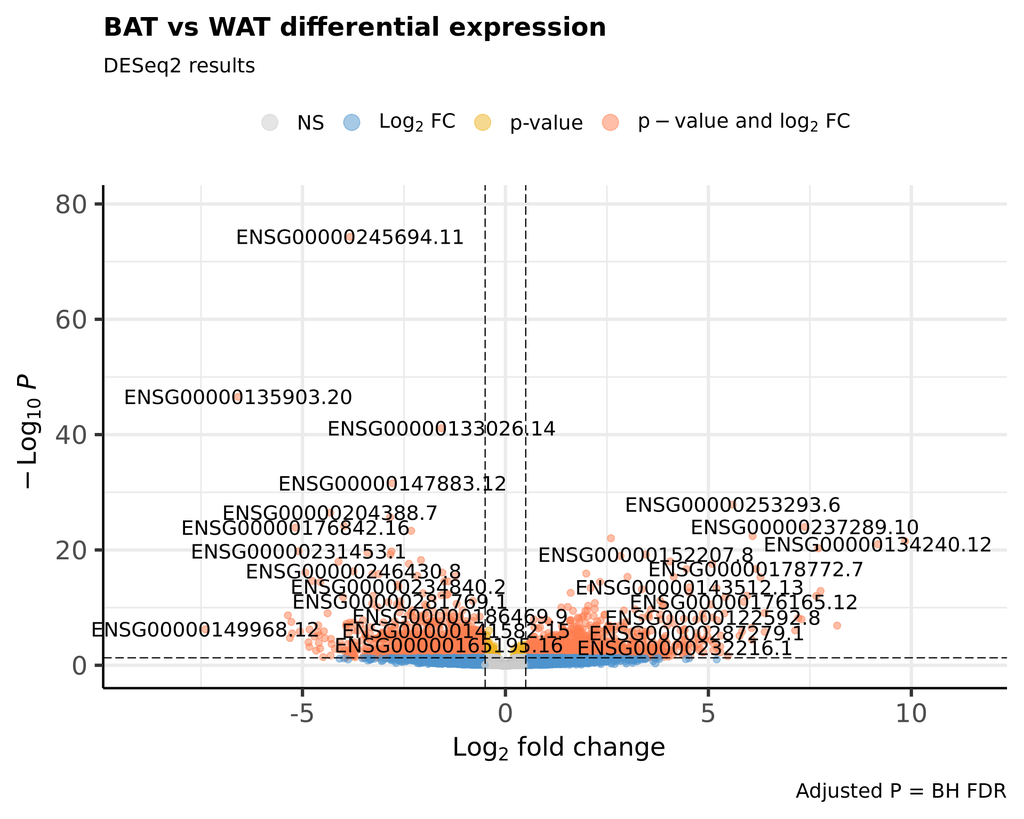

```r
library(EnhancedVolcano)

EnhancedVolcano(
  Vulcano,
  lab = Vulcano$label,
  x = "log2FoldChange",
  y = "padj",
  pCutoff = 0.05,
  FCcutoff = 0.5,
  title = "BAT vs WAT differential expression",
  subtitle = "DESeq2 results",
  caption = "Adjusted P = BH FDR",
  col = c("grey80", "steelblue3", "goldenrod2", "coral"))
```

Next, I will take the BAT samples (except for the `E387_7_brown_fat` sample that clusters with WAT) and merge them with the GTEx data to see how they compare globally.

## GTEX merging of BAT samples

### Generating BAT TPM values with RSEM and STAR

Working on a different cluster!

First, we need to download the GTEx annotation and FASTA files. I will use the same GENCODE v39 annotation that GTEx used for their v10 release to maximize comparability.

GTEx TPM values for other non-BAT tissues can be found [here](https://www.gtexportal.org/home/downloads/adult-gtex/metadata)

```bash
# same annotation as the one GTEX where using for v10
wget https://ftp.ebi.ac.uk/pub/databases/gencode/Gencode_human/release_39/gencode.v39.annotation.gtf.gz
gunzip -c gencode.v39.annotation.gtf.gz > gencode.v39.annotation.gtf

wget https://ftp.ebi.ac.uk/pub/databases/gencode/Gencode_human/release_39/GRCh38.primary_assembly.genome.fa.gz
gunzip GRCh38.primary_assembly.genome.fa.gz

# IMPORTANT! The FASTA file I downloaded from GTEX web page
```

Then, I will create the enviroment I will use to use. Since GTEx uses RSEM 1.3.3, I will use that same version to maximize comparability. I use `mamba` to create the enviroment and install the dependencies.

```bash
mamba create -n RSEM -y \
  star=2.7.10a \
  samtools \
  gcc \
  gxx \
  make \
  zlib \
  perl
```

```bash
wget https://github.com/deweylab/RSEM/archive/refs/tags/v1.3.3.tar.gz -O rsem-1.3.3.tar.gz
tar -xzf rsem-1.3.3.tar.gz
cd RSEM-1.3.3
make # to compile RSEM
```

After compiling RSEM, I will add it to my `PATH` so I can use it from anywhere in the terminal. Since I don’t have write permissions to modify the system-wide `PATH`, I will add it to my user-level `~/.bashrc` file.

```bash
echo 'export PATH=/storage/scratch01/groups/md/microproteins/BROWN_GTEx_TPM_STAR/Cohort_2/tools/RSEM-1.3.3:$PATH' >> ~/.bashrc
source ~/.bashrc
```

Reactivate the environment to apply the changes to `PATH`, then check that RSEM is available and the correct version is being used.

```bash
rsem-calculate-expression --version # should say RSEM v1.3.1, authors forgot to update the number
```

Then, I will submit the jobs to the cluster. First, I will build the STAR index for RSEM:

```bash
#!/bin/bash
#SBATCH --job-name=rsem_star_ref
#SBATCH --output=rsem_star_ref_%j.out
#SBATCH --error=rsem_star_ref_%j.err
#SBATCH --time=24:00:00
#SBATCH --cpus-per-task=8
#SBATCH --mem=64G

source ~/.bashrc
mamba activate RSEM

cd /storage/scratch01/groups/md/microproteins/BROWN_GTEx_TPM_STAR

rsem-prepare-reference \
  --gtf gencode.v39.annotation.gtf \
  --star \
  GRCh38.primary_assembly.genome.fa \
  rsem_star_reference/gencode_v39
```

Then, I will run RSEM with STAR for all the samples:

`run_rsem_star_all.sbatch`

```bash
#!/bin/bash
#SBATCH --job-name=rsem_star_all
#SBATCH --output=rsem_star_all_%j.out
#SBATCH --error=rsem_star_all_%j.err
#SBATCH --time=24:00:00
#SBATCH --cpus-per-task=8
#SBATCH --mem=48G

source ~/.bashrc
mamba activate RSEM

cd /storage/scratch01/groups/md/microproteins/BROWN_GTEx_TPM_STAR/Cohort_2

mkdir -p rsem_results

REF_PREFIX="/storage/scratch01/groups/md/microproteins/BROWN_GTEx_TPM_STAR/Cohort_2/rsem_star_reference/gencode_v39"
STAR_PATH=$(dirname "$(which STAR)")

for fastq in ERR*.fastq.gz; do
    sample=$(basename "$fastq" .fastq.gz)
    echo "Quantifying sample: $sample"

    rsem-calculate-expression \
        --star \
        --star-path "$STAR_PATH" \
        --star-gzipped-read-file \
        -p 8 \
        "$fastq" \
        "$REF_PREFIX" \
        "rsem_results/${sample}"

    echo "Done: $sample"
    echo "-----------------------------------------"
done
```

### Merging BATLAS RSEM TPM values with GTEx TPM values

I ran the following R script to compute the average TPM across all samples for each gene. I run it on the cluster using `RScript`. `compute_average_tpm.R`

```r
library(dplyr)
library(readr)
library(purrr)

# All gene-level result files
gene_files <- list.files(pattern = "\\.genes\\.results$")

# Read each file: gene_id + TPM, TPM column named by sample
read_one <- function(f) {
  sample <- sub("\\.genes\\.results$", "", f)
  read_tsv(f, show_col_types = FALSE) %>%
    select(gene_id, TPM) %>%
    rename(!!sample := TPM)}

gene_list <- lapply(gene_files, read_one)

# Merge on gene_id
merged_tpm <- reduce(gene_list, full_join, by = "gene_id")

# Replace NAs with 0
merged_tpm[is.na(merged_tpm)] <- 0

# Row-wise mean TPM
avg_tpm <- merged_tpm %>%
  rowwise() %>%
  mutate(mean_TPM = mean(c_across(-gene_id))) %>%
  ungroup() %>%
  select(gene_id, mean_TPM)

# Save
write_tsv(avg_tpm, "average_TPM_across_samples_cohort_2.tsv")
```

```r
data <- read_tsv("GTEx_Analysis_2022-06-06_v10_RNASeQCv2.4.2_gene_median_tpm.gct")
data <- data %>%
  mutate(Gene = sub("\\..*$", "", Gene))  # remove .version in ensembl id

bat_tpm <- read_tsv("average_TPM_across_samples_cohort_2.tsv") # quantificatoin using RSEM, same process GTEx used
bat_tpm_value_col <- intersect(c("BAT_TPM", "mean_TPM"), names(bat_tpm)) # I have to versions...

bat_tpm <- bat_tpm %>%
  mutate(
    Gene = sub("\\..*$", "", gene_id),  # remove .version in ensembl id
    Adipose_Brown = .data[[bat_tpm_value_col]]
  ) %>%
  dplyr::select(Gene, Adipose_Brown)

# annotate gene types
gene_types <- tryCatch({
  mart <- useEnsembl("ensembl", dataset = "hsapiens_gene_ensembl")
  getBM(
    attributes = c("ensembl_gene_id", "gene_biotype"),
    filters = "ensembl_gene_id",
    values = unique(data$Gene),
    mart = mart
  )
}, error = function(e) {
  message("biomaRt unavailable; proceeding without gene_biotype filtering. ", conditionMessage(e))
  NULL
})

data_pc <- if (!is.null(gene_types) && nrow(gene_types) > 0) {
  data %>%
    inner_join(gene_types, by = c("Gene" = "ensembl_gene_id")) %>%
    filter(gene_biotype == "protein_coding")
} else {
  data
}

merged_tpm <- data_pc %>%
  left_join(bat_tpm, by = "Gene", relationship = "many-to-many") # merge the GTEx TPM with the BAT TPM using the gene id as key. This is a many-to-many relationship because some genes have multiple transcripts, and thus multiple rows in the GTEx data, but only one row in the BAT TPM data (since RSEM quantifies at the gene level by summing across transcripts)

merged_tpm$Adipose_Brown <- as.numeric(merged_tpm$Adipose_Brown) # this gives us a "raw" TPM matrix

# GTEx does not provide nTPMs, but HPA does a two step normalization using the following approach:
# They do between-sample normalization using TMM (edgeR-style) across all samples within a dataset.

# Build and unnormalized TPM matrix
tissue_cols <- setdiff(colnames(merged_tpm), c("Gene", "Gene.name"))

tpm_mat <- merged_tpm %>%
  dplyr::select(-any_of(c("gene_biotype", "Gene", "Gene.name"))) %>%  # remove annotation cols if present; keep only tissues
  mutate(across(everything(), as.numeric)) %>%  # make columns numeric
  as.matrix() # turn into a matrix

rownames(tpm_mat) <- merged_tpm$Gene.name # or Gene

# Total TPM per tissue (column)
col_sums <- colSums(tpm_mat)

# pTPM = TPM / total_TPM_for_that_tissue * 1e6
pTPM <- sweep(tpm_mat, 2, col_sums, FUN = "/") * 1e6

library(edgeR) # edger for TMM normalization

# Treat pTPM as pseudo-counts in a DGEList
dge <- DGEList(counts = pTPM)

# Compute TMM normalization factors
dge <- calcNormFactors(dge, method = "TMM")

# Effective library sizes after TMM (edgeR always uses original lib.size * norm.factor)
eff_libsizes <- colSums(pTPM) * dge$samples$norm.factors

# nTPM = TMM-normalized pTPM, scaled back to per-million
nTPM_mat <- t( t(pTPM) / eff_libsizes ) * 1e6

nTPM_df <- nTPM_mat %>%
  as.data.frame() %>%
  rownames_to_column("Gene") %>%
  left_join(merged_tpm %>% dplyr::select(Gene), by = "Gene")

# Optional: reorder columns for convenience
nTPM_df <- nTPM_df %>%
  relocate(Gene)

write_csv(nTPM_df, "nTPM_df.csv")
```

### UMAP of the merged dataset

```r
# ============================================================
# UMAP background transcript abundance
# Uses correlation distance, no log, YES z-scoring
# ============================================================

library(uwot)
library(RColorBrewer)

nTPM_df <- read_csv("nTPM_df.csv")

# Build matrix (genes x tissues)
stopifnot(ncol(nTPM_df) >= 3)
stopifnot(colnames(nTPM_df)[1] %in% c("Symbol", "gene", "Gene", "Gene.name"))

nTPM_df <- nTPM_df %>%
  rename(Symbol = 1)

tissue_cols <- setdiff(colnames(nTPM_df), "Symbol")

expr_mat <- nTPM_df %>%
  dplyr::select(all_of(tissue_cols)) %>%
  mutate(across(everything(), as.numeric)) %>%
  as.matrix()

expr_mat_z <- t(scale(t(expr_mat))) # row-wise z-score

rownames(expr_mat_z) <- nTPM_df$Symbol

# Assign dominant tissue only if top >= 4x second in TPMs!
# BUT for building the signature matrix, we use expr_mat_z

ENRICHMENT_THRESHOLD <- 1

max1 <- apply(expr_mat, 1, max, na.rm = TRUE) # get the max value of each row
dominant_tissue <- tissue_cols[max.col(expr_mat, ties.method = "first")] # get the colname for each max value

second_max <- apply(expr_mat, 1, function(x) {
  x <- x[is.finite(x)]
  x_sorted <- sort(x, decreasing = TRUE) # sort them decreasing
  x_sorted[2]}) # get the second one

is_signature <- is.finite(max1) & (max1 > 0) & is.finite(second_max) &
  ((second_max == 0 & max1 > 0) | (max1 >= ENRICHMENT_THRESHOLD * second_max))

# Here we use the z-scored matrix
sig_genes <- rownames(expr_mat_z)[is_signature]
sig_mat   <- expr_mat_z[sig_genes, , drop = FALSE] # use the z-score matrix

message("Signature genes used for background UMAP: ", length(sig_genes))

# Fit UMAP on signature genes; keep model for transform. We will use seed = 3.
bg_umap <- uwot::umap(
  sig_mat,
  n_neighbors = 20, # 20 is a common default, but can be tuned based on the dataset size and expected local structure
  min_dist    = 0.1, # 0.1 is a common default, but can be tuned to control how tightly UMAP packs points together
  repulsion_strength = 1, #
  metric      = "correlation", # pearson correlation distance. This is for better visualization
  n_components = 2,
  ret_model = TRUE,
  verbose = TRUE,
  seed = 1999)

# With ret_model=TRUE, bg_umap is a LIST; coords are in $embedding
stopifnot(is.list(bg_umap), !is.null(bg_umap$embedding))

bg_emb <- as.matrix(bg_umap$embedding)
stopifnot(ncol(bg_emb) == 2)

bg_df <- tibble(
  Symbol = sig_genes,
  Dominant.tissue = dominant_tissue[match(sig_genes, rownames(expr_mat_z))],
  UMAP1 = bg_emb[, 1],
  UMAP2 = bg_emb[, 2])


# Tissue grouping based on GTEx sample annotations and manual curation. This is used for coloring the UMAP plot and for building the signature matrix later on.
# The grouping is somewhat subjective, but it is based on known biological relationships between tissues and their expected expression profiles.
cns_labels <- c(
  "Brain_Amygdala",
  "Brain_Anterior_cingulate_cortex_BA24",
  "Brain_Caudate_basal_ganglia",
  "Brain_Cerebellar_Hemisphere",
  "Brain_Cerebellum",
  "Brain_Cortex",
  "Brain_Frontal_Cortex_BA9",
  "Brain_Hippocampus",
  "Brain_Hypothalamus",
  "Brain_Nucleus_accumbens_basal_ganglia",
  "Brain_Putamen_basal_ganglia",
  "Brain_Spinal_cord_cervical_c-1",
  "Brain_Substantia_nigra"
)

colon <- c(
  "Colon_Sigmoid",
  "Colon_Transverse",
  "Colon_Transverse_Mixed_Cell",
  "Colon_Transverse_Mucosa",
  "Colon_Transverse_Muscularis"
)

liver <- c(
  "Liver",
  "Liver_Hepatocyte",
  "Liver_Mixed_Cell",
  "Liver_Portal_Tract"
)

esophagus <- c(
  "Esophagus_Gastroesophageal_Junction",
  "Esophagus_Mucosa",
  "Esophagus_Muscularis"
)

heart <- c(
  "Heart_Atrial_Appendage",
  "Heart_Left_Ventricle"
)

kidney <- c(
  "Kidney_Cortex",
  "Kidney_Medulla"
)

stomach <- c(
  "Stomach_Mixed_Cell",
  "Stomach_Mucosa",
  "Stomach_Muscularis"
)

female_sex_labels <- c(
  "Cervix_Ectocervix",
  "Cervix_Endocervix",
  "Ovary",
  "Vagina",
  "Uterus",
  "Fallopian_Tube"
)

male_sex_labels <- c(
  "Testis",
  "Prostate"
)

sex_labels <- c(
  "Testis",
  "Prostate",
  "Cervix_Ectocervix",
  "Cervix_Endocervix",
  "Ovary",
  "Vagina",
  "Uterus",
  "Fallopian_Tube"
)

small_intestine <- c(
  "Small_Intestine_Terminal_Ileum",
  "Small_Intestine_Terminal_Ileum_Lymphode_Aggregate",
  "Small_Intestine_Terminal_Ileum_Mixed_Cell"
)

pancreas <- c(
  "Pancreas",
  "Pancreas_Acini",
  "Pancreas_Islets",
  "Pancreas_Mixed_Cell"
)

arteries <- c(
  "Artery_Aorta",
  "Artery_Tibial",
  "Artery_Coronary"
)
skin <- c(
  "Skin_Not_Sun_Exposed_Suprapubic",
  "Skin_Sun_Exposed_Lower_leg"
)

fibroblasts  <- c("Cells_Cultured_fibroblasts")
limphocytes  <- c("Cells_EBV-transformed_lymphocytes")
tibial_nerve <- c("Nerve_Tibial")
whole_blood  <- c("Whole_Blood")

pool_tissue_group <- function(dominant) {
  dplyr::case_when(
    dominant %in% cns_labels ~ "CNS regions",

    dominant %in% female_sex_labels ~ "female sex organs",
    dominant %in% male_sex_labels ~ "male sex organs",
    # dominant %in% sex_labels ~ "sex organs",

    dominant %in% fibroblasts  ~ "fibroblasts",
    dominant %in% limphocytes  ~ "limphocytes",
    dominant %in% tibial_nerve ~ "tibial nerve",
    dominant %in% whole_blood  ~ "whole blood",

    dominant %in% arteries ~ "arteries",
    dominant %in% liver    ~ "liver",
    dominant %in% kidney   ~ "kidney",
    dominant %in% stomach  ~ "stomach",
    dominant == "Stomach"  ~ "stomach",
    dominant %in% esophagus ~ "esophagus",
    dominant %in% colon     ~ "colon",
    dominant %in% heart     ~ "heart muscle",

    dominant == "Adipose_Subcutaneous"     ~ "adipose tissue subcutaneous",
    dominant == "Adipose_Visceral_Omentum" ~ "adipose tissue omentum",
    dominant == "Adipose_Brown"            ~ "adipose tissue brown",

    dominant == "Lung" ~ "lung",
    dominant == "Adrenal_Gland" ~ "adrenal gland",
    dominant == "Muscle_Skeletal" ~ "skeletal muscle",
    dominant %in% skin ~ "skin",
    dominant == "Thyroid" ~ "thyroid gland",
    dominant == "Minor_Salivary_Gland" ~ "salivary gland",
    dominant == "Spleen" ~ "spleen",
    dominant == "Bladder" ~ "bladder",
    dominant %in% small_intestine ~ "small intestine",
    dominant %in% pancreas ~ "pancreas",
    dominant == "Pituitary" ~ "pituitary gland",
    dominant == "Breast_Mammary_Tissue" ~ "breast mammary tissue",

    TRUE ~ dominant
  )
}

bg_df <- bg_df %>% mutate(Tissue_group = pool_tissue_group(Dominant.tissue))

# Colors (same palette logic as the script)
tissue_colors <- c(
  "breast mammary tissue" = "#ff69b4",
  "fibroblasts"      = "#708bf5",
  "limphocytes"      = "#eeb5e4",
  "arteries"         = "#f58d89",
  "liver"            = "#ff0505",
  "kidney"           = "#ed2128",
  "CNS regions"      = "#dfb7f1",
  "female sex organs" = "#bffaff",
  "male sex organs" = "#8ffabb",
  "sex organs"       = "#037a32",
  "stomach"          = "#6BAED6",
  "esophagus"        = "#edf02d",
  "retina"           = "#367846",
  "colon"            = "#fc51db",
  "adrenal gland"    = "#8bc4af",
  "skeletal muscle"  = "#6e6785",
  "spinal cord"      = "#9E9AC8",
  "vWAT"             = "#fcbf68",
  "scWAT"            = "#ebcaa0",
  "BAT    "          = "#a67371",
  "spleen"           = "#07a88b",
  "lung"             = "#90CAF9",
  "thyroid gland"    = "#F091F8",
  "salivary gland"   = "#B39DDB",
  "heart muscle"     = "#3b0cf7",
  "pituitary gland"  = "#603bf5",
  "pancreas"         = "#3f558c",
  "skin"             = "#53c182",
  "small intestine"  = "#6a74e6",
  "arteries"         = "#f58d89",
  "tibial nerve"     = "#34daf8",
  "whole blood"      = "#f2555a",
  "bladder"          = "#f4a261")

all_groups   <- sort(unique(bg_df$Tissue_group))
extra_groups <- setdiff(all_groups, names(tissue_colors))
extra_cols <- setNames(
  colorRampPalette(brewer.pal(8, "Dark2"))(max(1, length(extra_groups))),
  extra_groups)

tissue_colors_full <- c(tissue_colors, extra_cols)
```

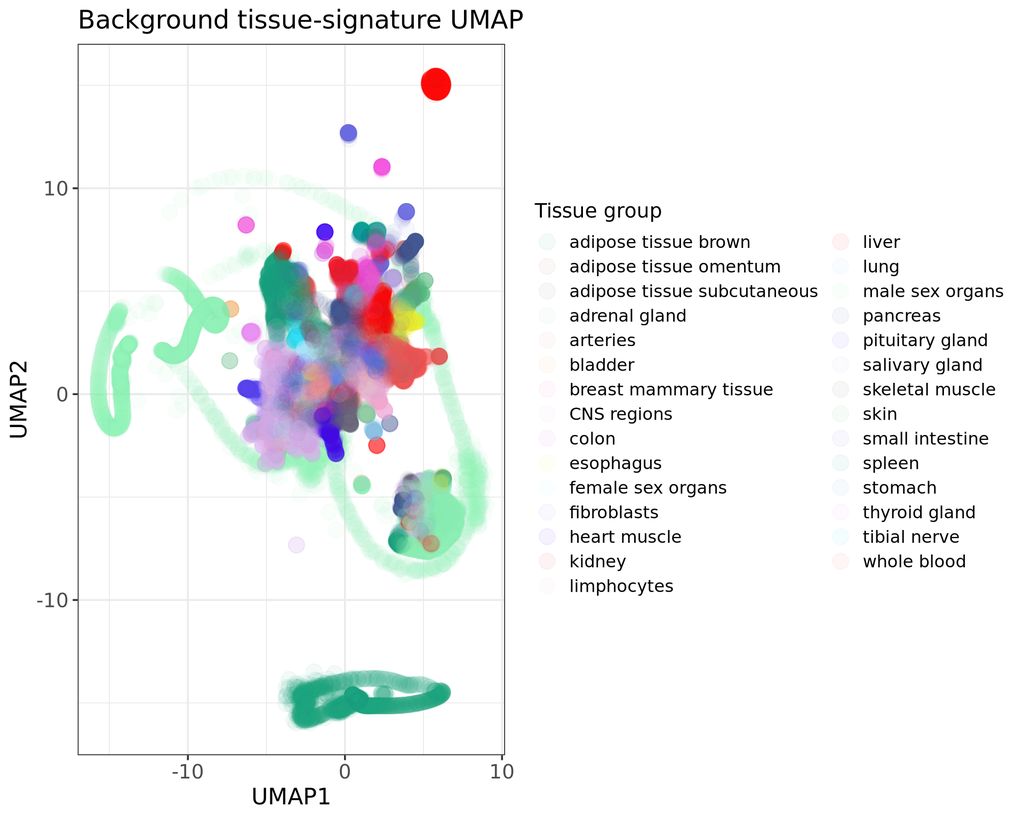

```r
# Plot
BG_ALPHA <- 0.05
BG_SIZE  <- 5

p <- ggplot() +
  geom_point(
    data = bg_df,
    aes(x = UMAP1, y = UMAP2, color = Tissue_group),
    alpha = BG_ALPHA, size = BG_SIZE,
    show.legend = TRUE
  ) +
  scale_color_manual(values = tissue_colors_full, name = "Tissue group") +
  theme_bw(base_family = "Arial", base_size = 14) +
  theme(
    plot.title   = element_text(size = 18),
    axis.title   = element_text(size = 16),
    axis.text    = element_text(size = 14),
    legend.title = element_text(size = 14),
    legend.text  = element_text(size = 12)
    # panel.grid = element_blank(),
    # legend.position = "right"
  ) +
  labs(
    title = "Background tissue-signature UMAP",
    # subtitle = paste0(
    #   "Signature rule: top >= ", ENRICHMENT_THRESHOLD, "x second; ",
    #   "UMAP: n_neighbors=", N_NEIGHBORS,
    #   ", min_dist=", MIN_DIST,
    #   ", metric=", METRIC
    # ),
    x = "UMAP1", y = "UMAP2")

print(p)
```

```r
message("Signature genes used for background UMAP: ", nrow(bg_df))
```